# Data Visualization

Chinazom

2024-04-04

```r
library(tidyverse)
```

```r
library(modeldata)
?ggplot
```

```
## starting httpd help server ... done
```

```r
?crickets
View(crickets)
```

# The basics

## Creating a chart for temp and rate

### geom_point known as **scatter plot** is good for two quantitative variable

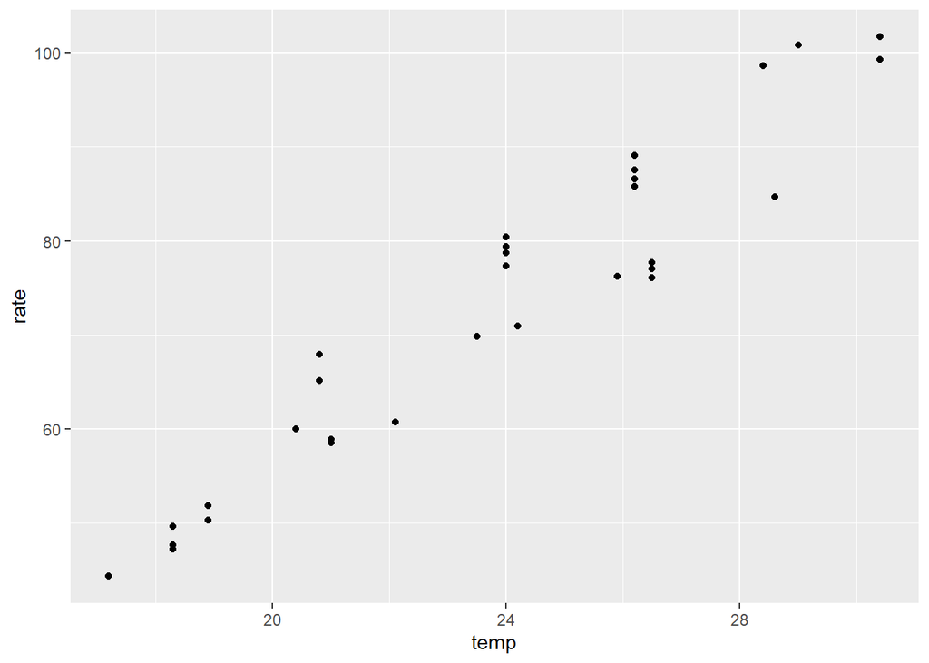

```r
ggplot(crickets, aes(x = temp,
                     y = rate)) +
  geom_point()
```

## To label the chart

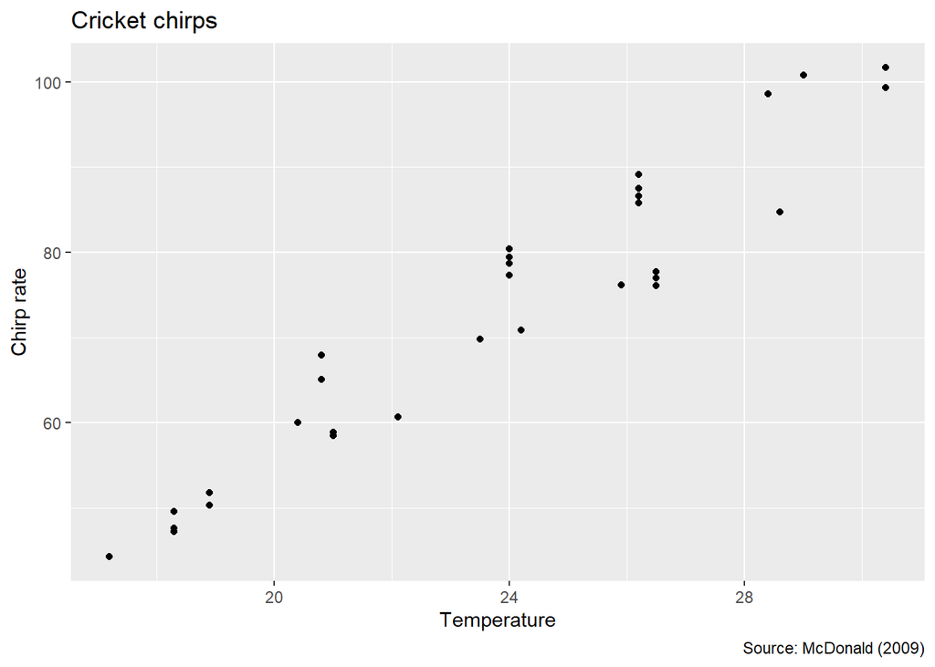

```r
ggplot(crickets, aes(x = temp,
                     y = rate)) +
  geom_point() +
  labs(x = "Temperature",
       y = "Chirp rate",
       title = "Cricket chirps",
       caption = "Source: McDonald (2009)")
```

#### To change the color of the charts based on the different species, you add color = species

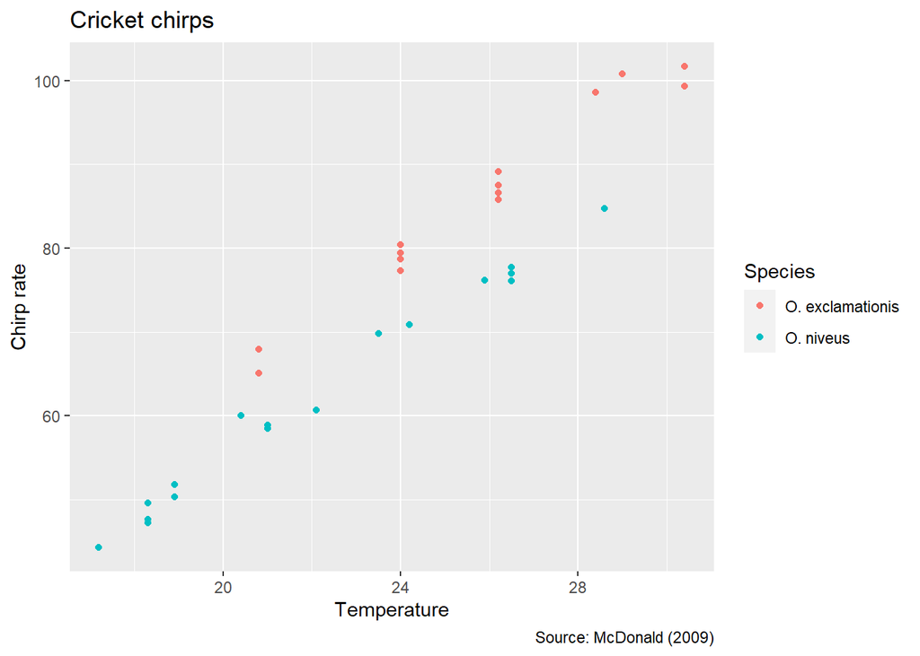

```r
ggplot(crickets, aes(x = temp,
                     y = rate,
                     color = species)) +
  geom_point() +
  labs(x = "Temperature",
       y = "Chirp rate",
       color = "Species",
       title = "Cricket chirps",
       caption = "Source: McDonald (2009)")
```

### To get a darker shade of the color using scale_color_brewer

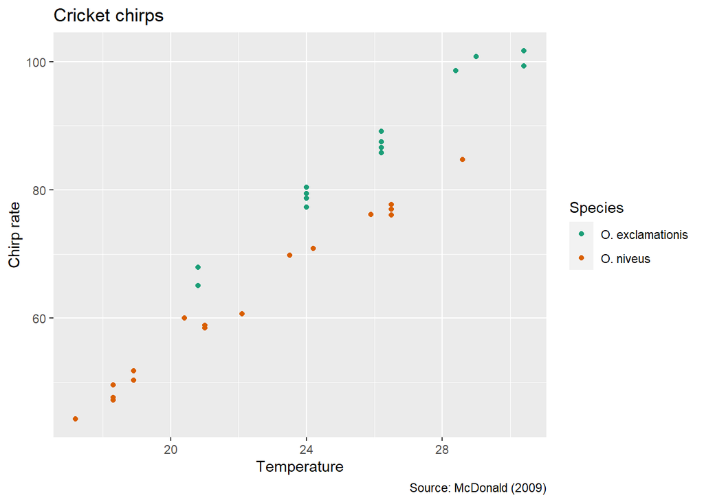

```r
ggplot(crickets, aes(x = temp,
                     y = rate,
                     color = species)) +
  geom_point() +
  labs(x = "Temperature",
       y = "Chirp rate",
       color = "Species",
       title = "Cricket chirps",
       caption = "Source: McDonald (2009)") +
       scale_color_brewer(palette = "Dark2")
```

### Modifiying basic properties of the plot

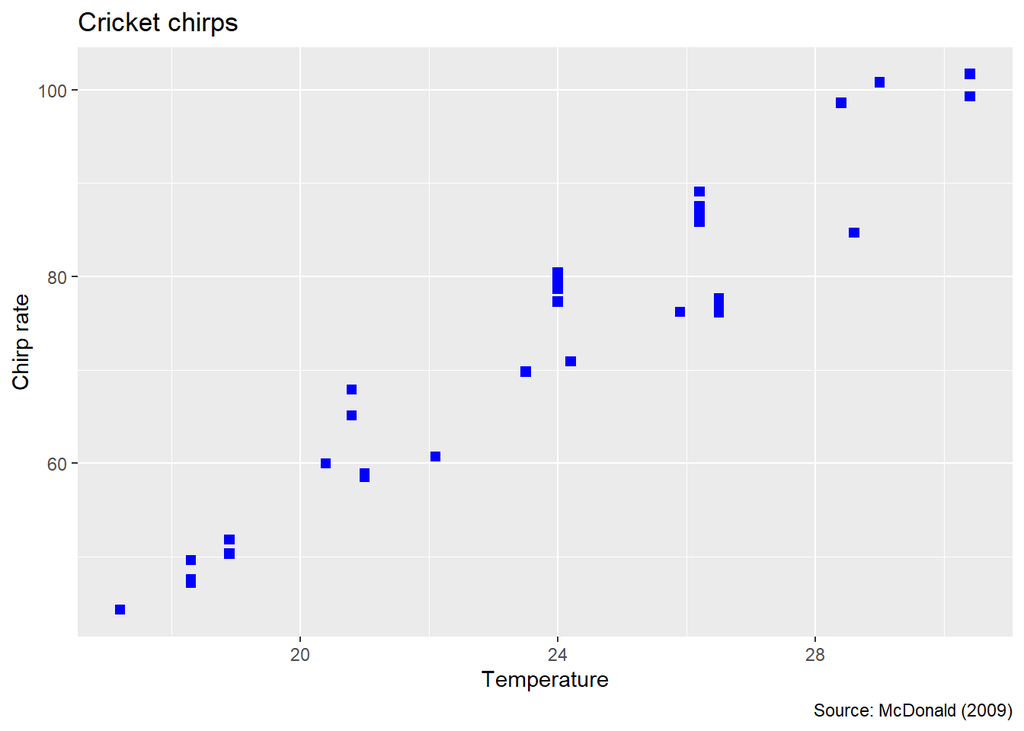

```r
ggplot(crickets, aes(x = temp,
                     y = rate)) +
  geom_point(color = "blue",
             size = 2,
             shape = "square") +
  labs(x = "Temperature",
       y = "Chirp rate",
       title = "Cricket chirps",
       caption = "Source: McDonald (2009)")
```

## Adding another layer geom_smooth to show the direction of the relationship

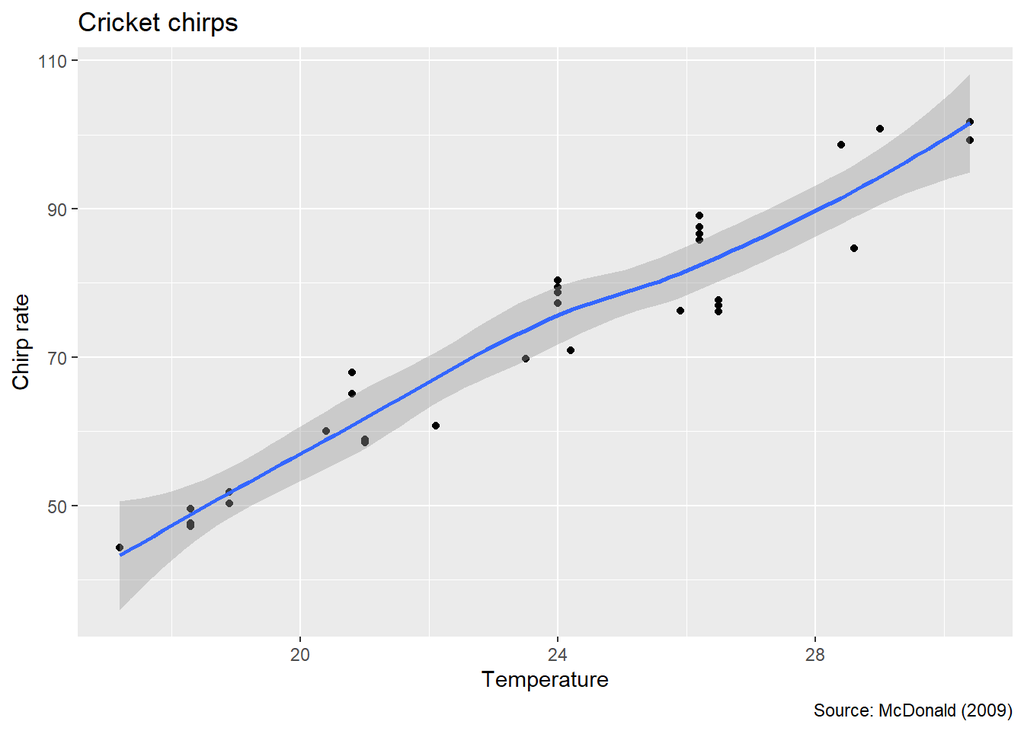

```r
ggplot(crickets, aes(x = temp,
                     y = rate)) +
  geom_point() +
  geom_smooth() +
  labs(x = "Temperature",
       y = "Chirp rate",
       title = "Cricket chirps",
       caption = "Source: McDonald (2009)")
```

### To modify the geom_smooth

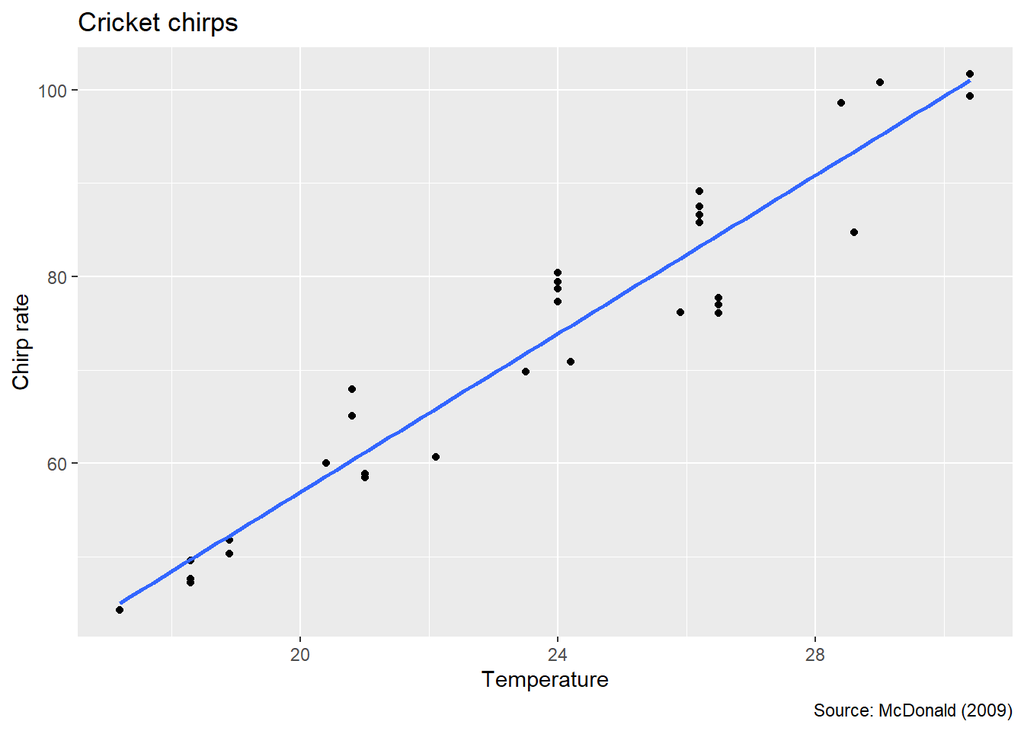

```r
ggplot(crickets, aes(x = temp,
                     y = rate)) +
  geom_point() +
  geom_smooth(method = "lm", # to make the line linear
              se = FALSE) + # se = false takes away the shadow from the line
  labs(x = "Temperature",
       y = "Chirp rate",
       title = "Cricket chirps",
       caption = "Source: McDonald (2009)")
```

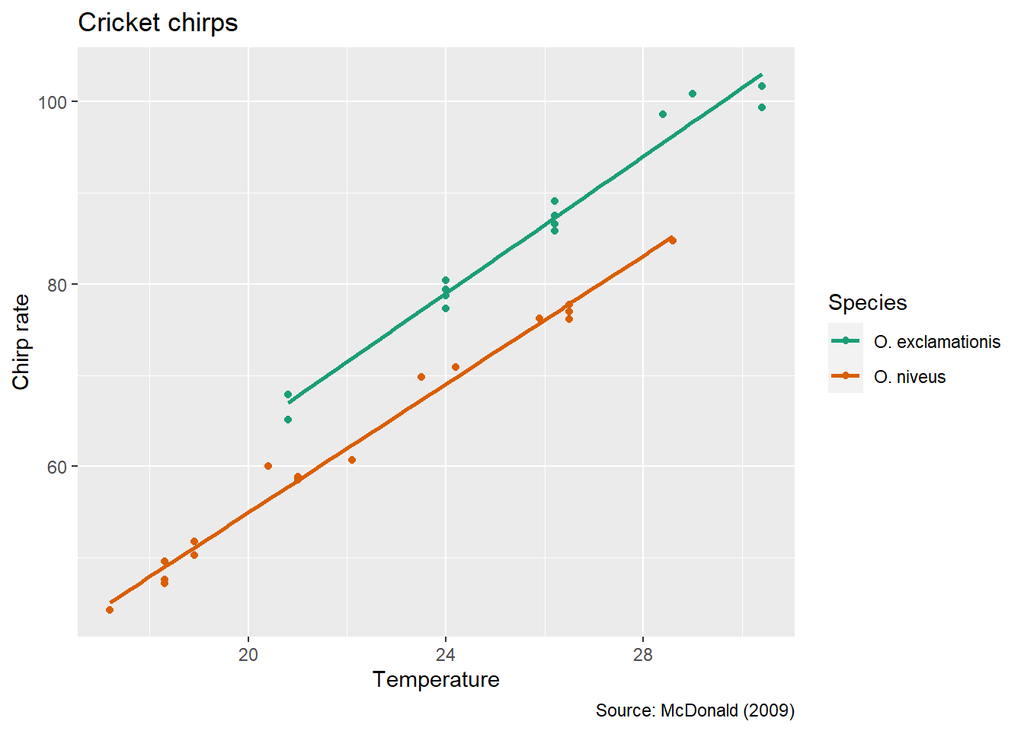

```r
ggplot(crickets, aes(x = temp,
                     y = rate,
                     color = species)) + # to differentiate between the different speciess
  geom_point() +
  geom_smooth(method = "lm",
              se = FALSE) +
  labs(x = "Temperature",
       y = "Chirp rate",
       color = "Species",
       title = "Cricket chirps",
       caption = "Source: McDonald (2009)") +
  scale_color_brewer(palette = "Dark2") # to make the colors darker
```

## Other plots ### Histogram- mostly use for one quantitative variable

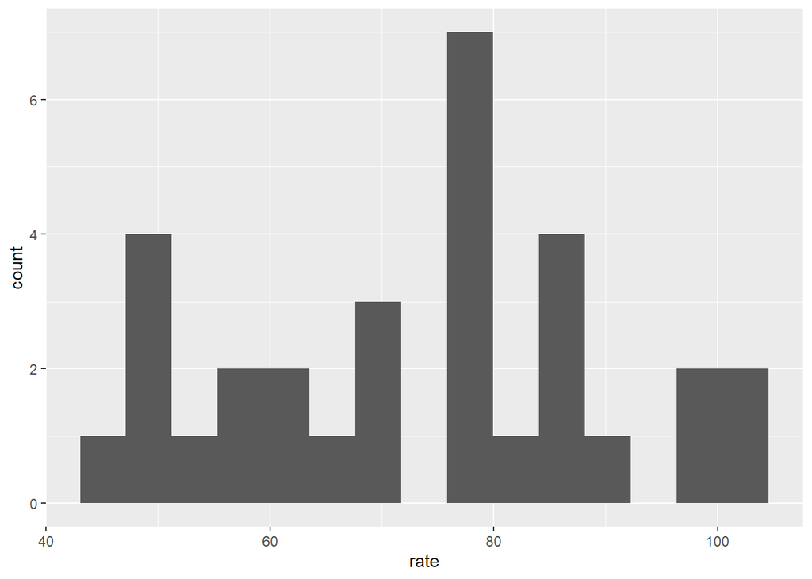

```r
ggplot(crickets, aes(x = rate)) +
  geom_histogram(bins = 15) #  bin represents a group or a segment of the data, interval into which the range of data values is divided
```

### Geom_frepoly - uses lines to represent the frequency distribution of a continuous variable.

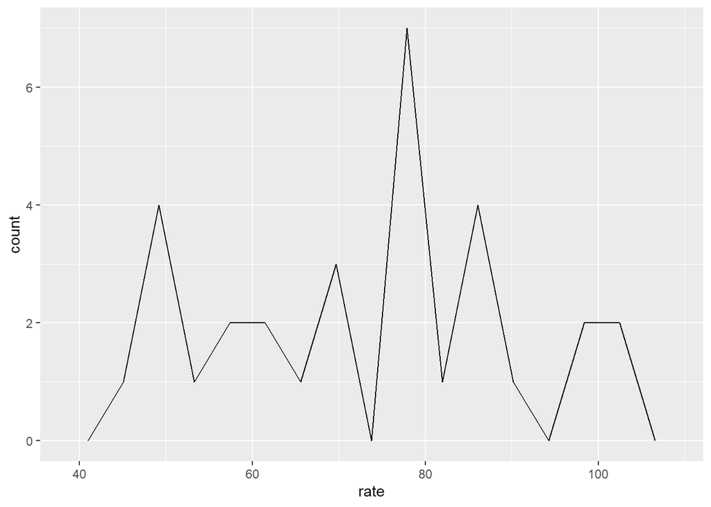

```r
ggplot(crickets, aes(x = rate)) +
  geom_freqpoly(bins = 15)
```

### Bar chart mostly used for one categorical variable

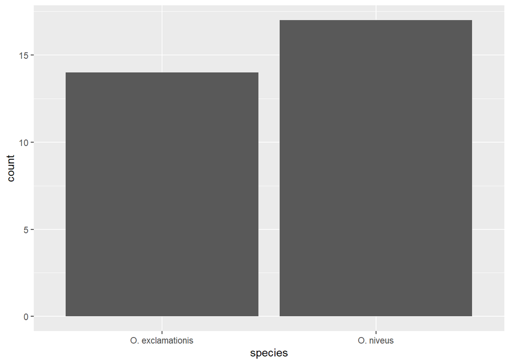

```r
ggplot(crickets, aes(x = species)) +
  geom_bar()
```

### Modification of the Bar chart output #### To change the outer and inner color of the bar

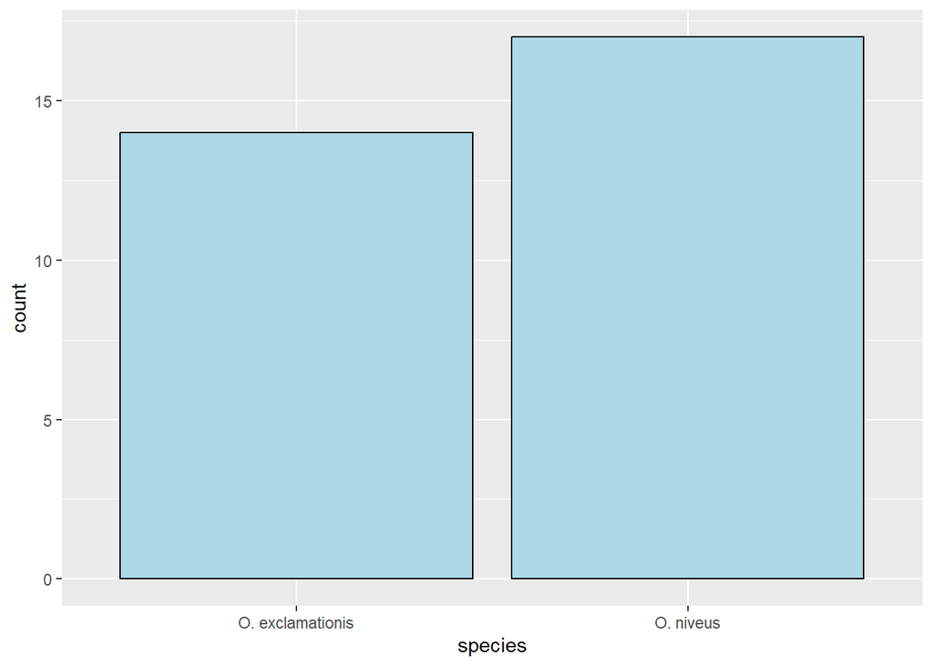

```r
ggplot(crickets, aes(x = species)) +
  geom_bar (color = "black", # color function works for the borders of the chart
fill = "lightblue") # fill for the inside
```

### To give the values in a variable different colors - here species

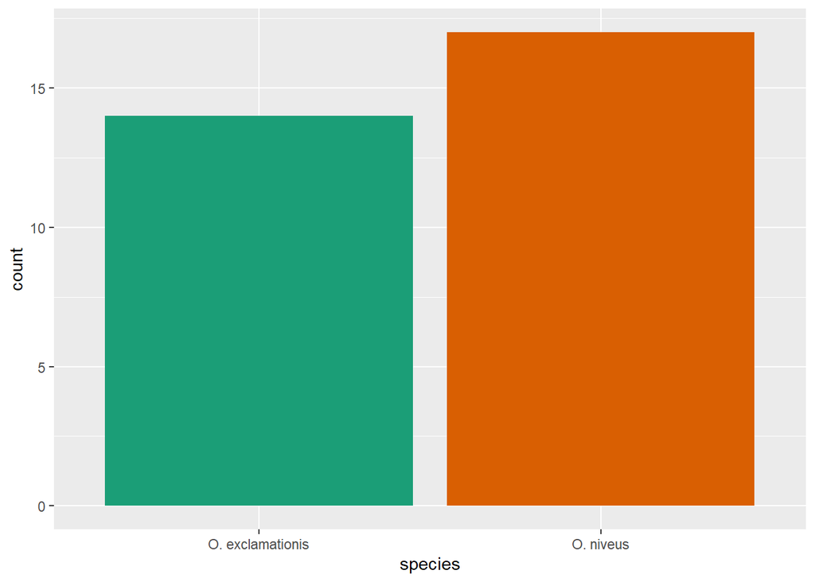

```r
ggplot(crickets, aes(x = species,
                     fill = species)) +
  geom_bar(show.legend = FALSE) + # to remove the legend from the chart
  scale_fill_brewer(palette = "Dark2") # to make the fill darker
```

### Geom_boxplot is good for one categorical and one quantitative variables

#### Boxplot is a visual representation of your 5 number summary; minimum - the line below

#### 1st quartile, the 2nd quartile which is the medium (the line in-between ), the 3rd quartile and the max - the line above

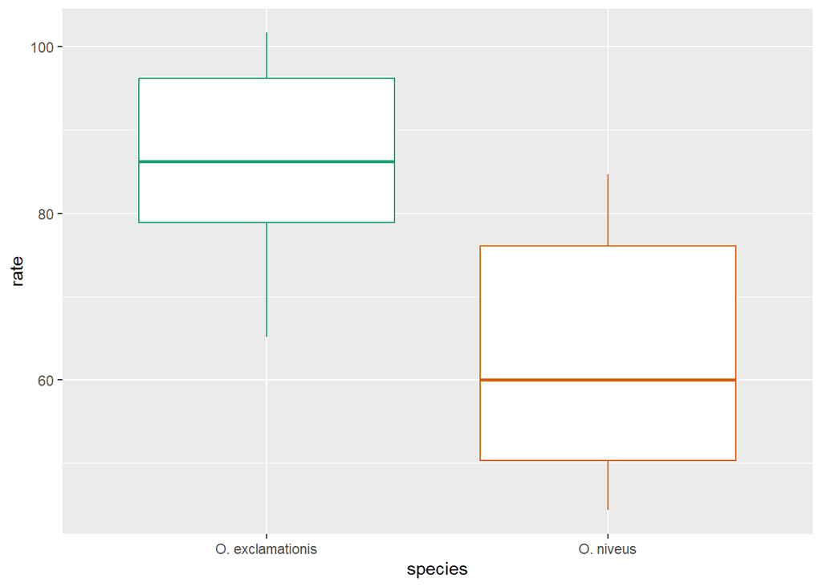

```r
ggplot(crickets, aes(x = species,
                     y = rate,
                     color = species)) +
  geom_boxplot(show.legend = FALSE) +
  scale_color_brewer(palette = "Dark2") # To make the color darker
```

### Theme() - control all non-data display. Use theme() if you just need to tweak the display of an existing, we have theme.minimal,classic,bw,light etc

#### To remove the gray background in the chart using theme minimal

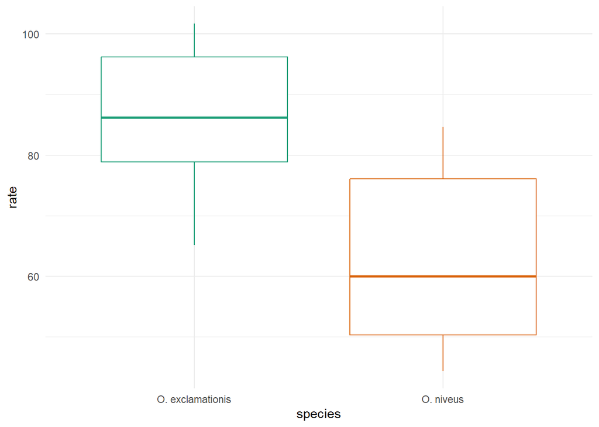

```r
ggplot(crickets, aes(x = species,
                     y = rate,
                     color = species)) +
  geom_boxplot(show.legend = FALSE) +
  scale_color_brewer(palette = "Dark2") +
  theme_minimal()
```

### Faceting

#### Without Faceting

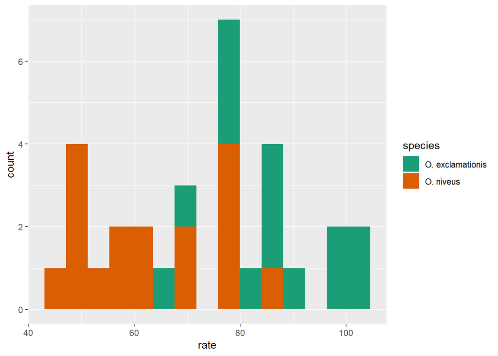

```r
ggplot(crickets, aes(x = rate,
                     fill = species)) +
  geom_histogram(bins = 15) +
  scale_fill_brewer(palette = "Dark2")
```

#### With faceting

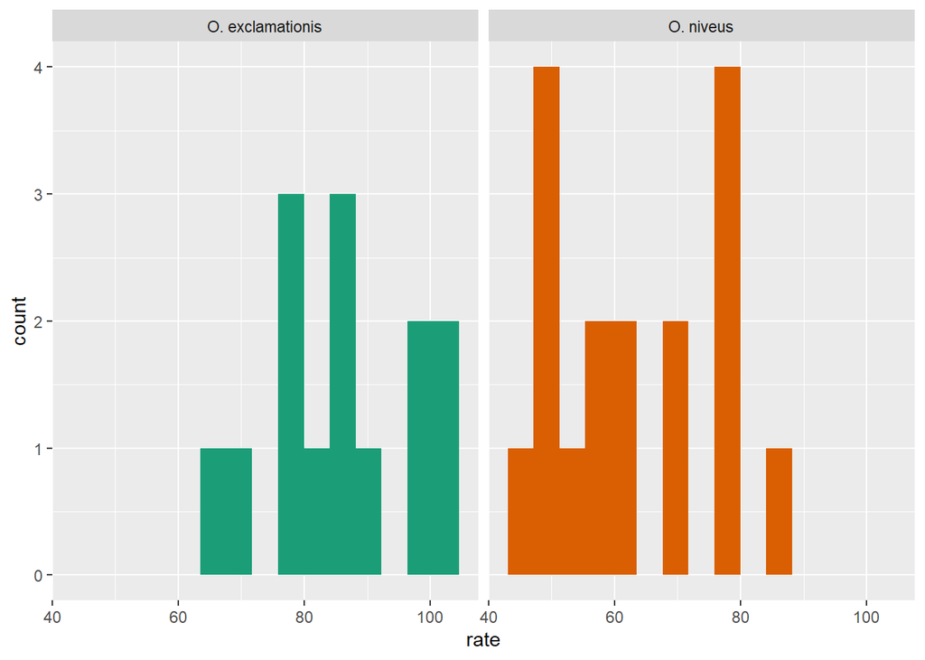

```r
ggplot(crickets, aes(x = rate,
                     fill = species)) +
  geom_histogram(bins = 15,
                 show.legend = FALSE) +
  facet_wrap(~species) +
  scale_fill_brewer(palette = "Dark2")
```

#### To have just one column - the second bar will be below the first

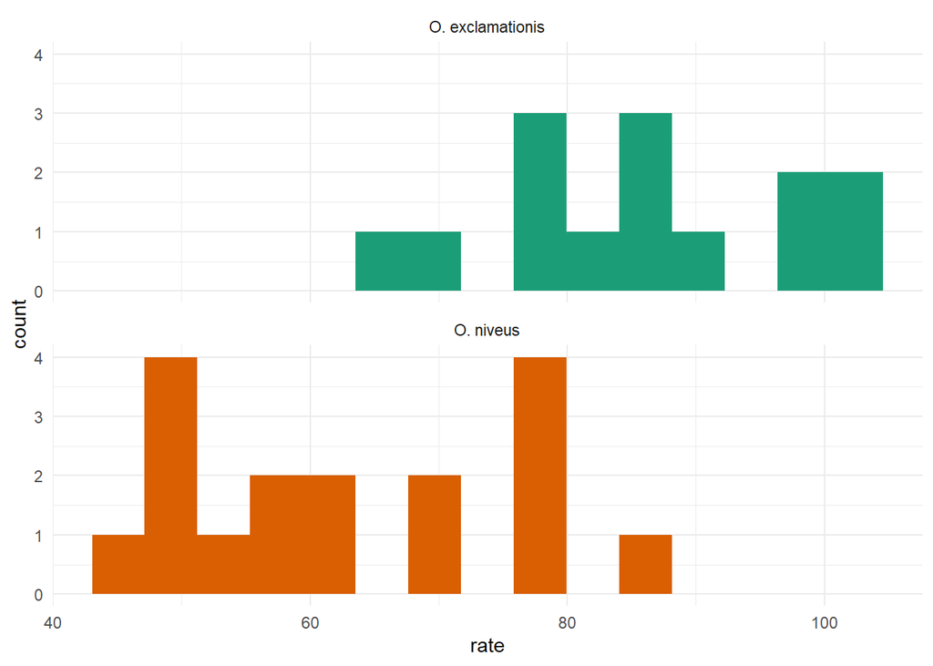

```r
ggplot(crickets, aes(x = rate,
                     fill = species)) +
  geom_histogram(bins = 15,
                 show.legend = FALSE) +
  facet_wrap(~species,
             ncol = 1) +
  scale_fill_brewer(palette = "Dark2") +
  theme_minimal()
```